# Modelaje Epidemiológico en `R`

Limpieza de bases y estadística descriptiva I

Rodrigo Zepeda

2019-07-19

# Estadística descriptiva y limpieza de bases

Existen dos formas de limpiar bases en `R`. La “clásica” usando sólo las funciones de `R` (como `which`, `subset` e identificadores de columnas) y la “nueva” (y más sencilla) usando el paquete de `tidyverse`. Yo estoy seguro que si ya conoces otro programa estadístico (por ejemplo `STATA`) te será mucho más fácil continuar limpiando tu base en èl. Aprenderemos a hacerlo en `R` de todas formas para entender cómo funciona ¡capaz que te convence!

Primero que nada, carguemos la librería de `tidyverse`:

```r
#No olvides instalarla con install.packages si aún
#no lo has hecho
library("tidyverse")
```

# Descripción de una base de datos

Vamos a leer la base de datos `conjunto_de_datos_defunciones_generales_2017.CSV` la cual contiene el registro de mortalidad en México para el año `2017`:

```r
#No olvides el directorio
mortalidad.2017 <- read.csv("conjunto_de_datos_defunciones_generales_2017.CSV")
```

Aquí sólo muestro las primeras columnas de la base y sus primeras entradas:

| ent_regis | mun_regis | ent_resid | mun_resid | tloc_resid | loc_resid |
| --- | --- | --- | --- | --- | --- |
| 1 | 1 | 1 | 1 | 15 | 1 |
| 1 | 9 | 1 | 9 | 1 | 16 |
| 1 | 1 | 1 | 1 | 15 | 1 |
| 1 | 6 | 1 | 6 | 8 | 1 |
| 1 | 1 | 1 | 1 | 15 | 1 |
| 1 | 1 | 1 | 1 | 15 | 1 |

La función `glimpse` nos permite darnos una idea de la composición de nuestros datos:

```r
mortalidad.2017 %>% glimpse()
```

```
## Observations: 703,047
## Variables: 7
## $ ent_regis  <dbl> 1, 1, 1, 1, 1, 1, 1, 1, 1, 1, 1, 1, 1, 1, 1, 1, 1, 1,…
## $ mun_regis  <dbl> 1, 9, 1, 6, 1, 1, 1, 1, 1, 1, 1, 1, 1, 1, 1, 1, 1, 1,…
## $ ent_resid  <dbl> 1, 1, 1, 1, 1, 1, 1, 1, 1, 1, 1, 1, 1, 1, 1, 1, 1, 1,…
## $ mun_resid  <dbl> 1, 9, 1, 6, 1, 1, 1, 1, 1, 1, 1, 2, 1, 1, 1, 1, 1, 1,…
## $ tloc_resid <int> 15, 1, 15, 8, 15, 15, 15, 15, 15, 5, 15, 1, 15, 15, 1…
## $ loc_resid  <dbl> 1, 16, 1, 1, 1, 1, 1, 1, 1, 1025, 1, 55, 1, 1, 7777, …
## $ ent_ocurr  <dbl> 1, 1, 1, 1, 1, 1, 1, 1, 1, 1, 1, 1, 1, 1, 1, 1, 1, 1,…
```

El comando `ncol` nos muestra el número de columnas en la base de datos y `nrow` nos muestra el número de filas en la base de datos.

```r
ncol(mortalidad.2017) #Columnas
```

```
## [1] 59
```

```r
nrow(mortalidad.2017) #Filas
```

```
## [1] 703047
```

Podemos ver los nombres de las columnas de la base de datos con `colnames`:

```r
#Mostramos las columnas
colnames(mortalidad.2017)
```

```
##  [1] "ent_regis"  "mun_regis"  "ent_resid"  "mun_resid"  "tloc_resid"
##  [6] "loc_resid"  "ent_ocurr"  "mun_ocurr"  "tloc_ocurr" "loc_ocurr"
## [11] "causa_def"  "lista_mex"  "sexo"       "edad"       "dia_ocurr"
## [16] "mes_ocurr"  "anio_ocur"  "dia_regis"  "mes_regis"  "anio_regis"
## [21] "dia_nacim"  "mes_nacim"  "anio_nacim" "ocupacion"  "escolarida"
## [26] "edo_civil"  "presunto"   "ocurr_trab" "lugar_ocur" "necropsia"
## [31] "asist_medi" "sitio_ocur" "cond_cert"  "nacionalid" "derechohab"
## [36] "embarazo"   "rel_emba"   "horas"      "minutos"    "capitulo"
## [41] "grupo"      "lista1"     "gr_lismex"  "vio_fami"   "area_ur"
## [46] "edad_agru"  "complicaro" "dia_cert"   "mes_cert"   "anio_cert"
## [51] "maternas"   "lengua"     "cond_act"   "par_agre"   "ent_ocules"
## [56] "mun_ocules" "loc_ocules" "razon_m"    "dis_re_oax"
```

Una descripción de las variables las puedes encontrar en el archivo `diccionario_datos_defunciones_generales_2017.csv`. Donde aparece como sigue:

| NEMÓNICO | NOMBRE_CAMPO |
| --- | --- |
| ent_regis | Entidad Registro |
| mun_regis | Municipio Registro |
| ent_resid | Entidad Residencia |
| mun_resid | Municipio Residencia |
| tloc_resid | Tamaño Localidad Residencia |
| loc_resid | Clave Localidad de Residencia |
| ent_ocurr | Entidad Ocurrencia |
| mun_ocurr | Municipio Ocurrencia |
| tloc_ocurr | Tamaño de Localidad Ocurrencia |
| loc_ocur | Clave Localidad de Ocurrencia |
| causa_def | Causa Defunción (Lista Detallada) |
| lista_mex | Causa Defunción (Lista Mexicana) |
| sexo | Sexo |
| edad | Edad |
| dia_ocurr | Día Defunción |
| mes_ocurr | Mes Defunción |
| anio_ocur | Año Defunción |
| dia_regis | Día Registro |
| mes_regis | Mes Registro |
| anio_regis | Año Registro |
| dia_nacim | Día Nacimiento |
| mes_nacim | Mes Nacimiento |
| anio_nacim | Año Nacimiento |
| ocupacion | Ocupación |
| escolarida | Escolaridad |
| edo_civil | Estado Conyugal |
| presunto | Presunto |
| ocurr_trab | Ocurrió Trabajo |
| lugar_ocur | Sitio donde Ocurrio la Lesión |
| necropsia | Necropsia |
| asist_medi | Asistencia Médica |
| sitio_ocur | Sitio donde Ocurrio la Defunción |
| cond_cert | Certificada Por |
| nacionalid | Nacionalidad |
| derechohab | Derechohabiencia |
| embarazo | Condición de embarazo |
| rel_emba | Causas relacionadas con embarazo |
| horas | Hora de la defunción |
| minutos | Minuto de la defunción |
| capitulo | Capitulo |
| grupo | Grupo |
| lista1 | Lista1 |
| gr_lismex | Grupos lista mexicana |
| vio_fami | Violencia Familiar |
| area_ur | Area Urbano Rural |
| edad_agru | Edad agrupada |
| complicaro | Complicaron el embarazo |
| dia_cert | Día de Certificación |
| mes_cert | Mes de Certificación |
| anio_cert | Año de Certificación |
| maternas | Maternas |
| lengua | Lengua indígena |
| cond_act | Condición de Actividad económica |
| par_agre | Parentesco del presunto agresor |
| ent_ocules | Entidad Ocurrencia de la lesión |
| mun_ocules | Municipio Ocurrencia de la lesión |
| loc_ocules | Clave Localidad de Ocurrencia de la lesión |
| razon_m | Razón Materna |
| dis_re_oax | Distritos de Oaxaca |

Una vez tenemos una base de datos podemos analizar sus entradas usando el nombre de la base y corchetes. Por ejemplo:

```r
#Obtengo todo el registro de la columna sexo
mortalidad.2017[ ,"sexo"]
```

```
## [1] 2 2 1 2 2 1
```

También podemos usar el número de columna:

```r
#Me regresa las observaciones de la columna 2
#dada por mun_regis
mortalidad.2017[ ,2]
```

```
## [1] 1 9 1 6 1 1
```

También podemos acceder a la base por renglones. Por ejemplo, así vemos el tercer renglón:

```r
mortalidad.2017[3, ]
```

```
##   ent_regis mun_regis ent_resid mun_resid tloc_resid loc_resid
## 3         1         1         1         1         15         1
```

Finalmente, podemos combinar la primer entrada de la columna `lista1` se vería así:

```r
mortalidad.2017[1, "lista1"]
```

```
## [1] 69
```

En resumen, la notación siempre es de la siguiente forma:
$$\text{Base.de.datos}[\underbrace{f}_{fila},\overbrace{c}^{columna}]$$
Esta notación `notación matricial` estándar en el mundo de computación y de las matemáticas. Siempre siempre primero es fila luego columna. ¡No lo olvides pues nos será útil para los modelos!

Otra forma de seleccionar una columna es con $ seguido del nombre de la columna. Por ejemplo:

```r
mortalidad.2017$edo_civil
```

```
## [1] 3 5 3 3 2 5
```

Por ciertos errores en los que se pueden incurrir al crear funciones, se recomienda que se utilice siempre la notación de doble corchete y se evite el signo de $. Pero ambos métodos funcionan. Sólo recuerda que la notación es así:

$$\text{Base.de.datos}\$\text{Columna}[\underbrace{f}_{\text{Fila}}]$$

Una última opción es con `select`:

```r
mortalidad.2017 %>% select(c("edo_civil"))
```

```
## [1] 3 5 3 3 2 5
```

la cual nos regresa la columna de estado civil. El comando [`select`](https://dplyr.tidyverse.org/reference/select.html) es bastante útil si, por ejemplo, no recordamos exactamente el nombre de la columna. Por ejemplo, si sólo recordamos que tiene la palabra `"civil"` pero no exactamente cómo se escribe podemos usar `contains`:

```r
#Podemos usar contains si recordamos que dice civil
#pero no el nombre completo
mortalidad.2017 %>% select(contains("civil"))
```

```
##   edo_civil
## 1         3
## 2         5
## 3         3
## 4         3
## 5         2
## 6         5
```

Podemos preguntarnos, de igual manera por la 7a entrada de `edo_civil` haciendo:

```r
mortalidad.2017$edo_civil[7]
```

```
## [1] 5
```

Lo cual es equivalente a la forma anterior:

```r
mortalidad.2017[7, "edo_civil"]
```

En el caso del `tidyverse` el equivalente a `select`, para elegir fila, el equivalente se conoce como `slice`:

```r
#Selecciona la fila 11
mortalidad.2017 %>% slice(11)
```

```
##   ent_regis mun_regis ent_resid mun_resid tloc_resid loc_resid ent_ocurr
## 1         1         1         1         1         15         1         1
##   mun_ocurr tloc_ocurr loc_ocurr causa_def lista_mex sexo edad dia_ocurr
## 1         1         15         1      C170       09C    1 4060        18
##   mes_ocurr anio_ocur dia_regis mes_regis anio_regis dia_nacim mes_nacim
## 1        12      2016         3         1       2017        26         2
##   anio_nacim ocupacion escolarida edo_civil presunto ocurr_trab lugar_ocur
## 1       1956         2          9         5        8          8         88
##   necropsia asist_medi sitio_ocur cond_cert nacionalid derechohab embarazo
## 1         2          1         11         1          1          1        8
##   rel_emba horas minutos capitulo grupo lista1 gr_lismex vio_fami area_ur
## 1        8    19      10        2     2     46        09        8       1
##   edad_agru complicaro dia_cert mes_cert anio_cert maternas lengua
## 1        17          8       19       12      2016               2
##   cond_act par_agre ent_ocules mun_ocules loc_ocules razon_m dis_re_oax
## 1        1       88         88        888       8888       0        999
```

Podemos combinar multiples argumentos con `%>%`:

En el mismo renglón debe estar el `%>%` que el último comando para no generar error

```r
mortalidad.2017 %>%
  select(c("sexo","edo_civil")) %>%
  slice(11:20)
```

```
##    sexo edo_civil
## 1     1         5
## 2     1         5
## 3     2         3
## 4     1         5
## 5     1         5
## 6     2         2
## 7     1         5
## 8     1         5
## 9     2         9
## 10    1         5
```

Esta forma de combinación con `pipes` (`%>%`) será bastante útil más adelante.

Para seleccionar múltiples filas o columnas, como vimos en el ejemplo anterior, hay que crear un vector usando `c`. Un vector es una lista ordenada de variables del mismo tipo. Por ejemplo:

Se llama `c` por `concatenate` (concatenar).

```r
mi.vector <- c(1, 141, 12)
```

Es un vector de 3 entradas. De hecho, la forma de acceder a sus entradas es la misma que la de los `data.frames` con un agregado: ¡sólo hay filas, no hay columnas!

Intuitivamente podemos pensar un vector como una columna de una base de datos. En ella todas las variables son del mismo tipo.

Para acceder a las entradas de un vector es de la siguiente forma:

```r
#Para un vector sólo pongo el número de entrada ¡no hay columna!
mi.vector[2] #entrada 2
```

```
## [1] 141
```

En general la notación es la siguiente:
$$\text{vector}[\underbrace{i}_{\text{Entrada}}]$$

```r
#Regresa el nombre de la 5a columna
colnames(mortalidad.2017)[5]
```

```
## [1] "tloc_resid"
```

La pregunta también puede hacerse al revés: podemos pedirle a `R` que nos conteste cuál es el número de columna para una columna dada. Por ejemplo, ¿cuál es el número de columna para `edad`?

```r
#Preguntamos a R cuál de las columnas se llama edad
which(colnames(mortalidad.2017) == "edad")
```

```
## [1] 14
```

Nota que si preguntamos por una columna que no existe, `R` nos regresa lo siguiente:

```r
#Preguntamos a R cuál de las columnas se llama edad
which(colnames(mortalidad.2017) == "Paraguas")
```

```
## integer(0)
```

Esto significa que no hay ninguna columna con ese nombre. Finalmente, nota que el which puede regresar múltiples resultados si las cosas se repiten. Por ejemplo, el siguiente comando nos regresa las múltiples entradas del vector `nombres.de.amigos` donde hay un amigo que tiene el nombre de `Alejandro`:

```r
#Creo un vector con nombres de mis amigos
nombres.de.amigos <- c("Alejandro", "Beatriz", "Alejandro", "Carla")

#Pregunto por cuáles entradas contienen a Alejandro
which(nombres.de.amigos == "Alejandro")
```

```
## [1] 1 3
```

Finalmente, podemos usar vectores para seleccionar múltiples columnas y filas, por ejemplo si deseo seleccionar, de la base, las columnas de `sexo` y `edad`:

```r
mortalidad.2017[ , c("sexo", "edad")]
```

```
##   sexo edad
## 1    2 4068
## 2    2 4090
## 3    1 4088
## 4    2 4096
## 5    2 4051
## 6    1 4078
```

Finalmente si quiero seleccionar sólo algunos renglones puedo ponerlos en un vector:

```r
#Selecciona sólo el renglón 1 y el 7
mortalidad.2017[c(1, 7), c("sexo", "edad")]
```

```
##   sexo edad
## 1    2 4068
## 7    1 4070
```

Mientras que el `:` selecciona *del renglón 1 al renglón 7*

```r
#Selecciona del 1 al 7
mortalidad.2017[1:7, c("sexo", "edad")]
```

```
##   sexo edad
## 1    2 4068
## 2    2 4090
## 3    1 4088
## 4    2 4096
## 5    2 4051
## 6    1 4078
## 7    1 4070
```

El equivalente usando `select` y `slice` es:

```r
mortalidad.2017 %>%
  select(c("sexo","edad")) %>%
  slice(1:7)
```

```
##   sexo edad
## 1    2 4068
## 2    2 4090
## 3    1 4088
## 4    2 4096
## 5    2 4051
## 6    1 4078
## 7    1 4070
```

**NOTA** Los dos puntos no funcionan para seleccionar columnas usando los nombres de las columnas como caracteres:

```r
#Selecciona renglones del 2 al 7
#y las columnas 5 a 9
mortalidad.2017[2:7, 5:9]
```

```
##   tloc_resid loc_resid ent_ocurr mun_ocurr tloc_ocurr
## 2          1        16         1         9          1
## 3         15         1         1         1         15
## 4          8         1         1         6          8
## 5         15         1         1         1         15
## 6         15         1         1         1         15
## 7         15         1         1         1         15
```

Los `:` son una forma corta de hacer vectores, por eso los usamos:

```r
9:15
```

```
## [1]  9 10 11 12 13 14 15
```

## Ejercicios

1. Lee el archivo `diversidad_dieta_adultos_251116.dta` el cual contiene el cuestionario de frecuencia de consumo de nutrimentos de la encuesta nacional de salud y nutrición (ENSANUT) 2016. Para ello usa el comando `read_dta` de la librería `haven` o bien en `RStudio > Import Dataset > From STATA`.
1. Determina los nombres de todas las columnas de las variables usando `R` (no vale ver el archivo).
2. Determina el número de renglones y el número de filas totales de la base.
3. Encuentra cuál fila contiene el `folio_sel` dado por: 09002000107920110041.
4. Regresa todas las mediciones para la 7676a fila.
5. Regresa la 5a columna.
6. Obtén el nombre de la 49 columna.
7. Obtén la entrada en la columna `5` y fila `14`.
2. Considera la base de datos creada por el siguiente código:

```r
base.inventada <- data.frame(Tiempo = rexp(100),
                             Enfermo = rbinom(100, 83, 1/3))
```

Determina qué ocasionó los resultados siguientes:

1. ¿Por qué da error?

```r
#Primer error
base.inventada[ , 200]
```

```
## Error in `[.data.frame`(base.inventada, , 200): undefined columns selected
```

2. ¿Por qué da `NA`?

```r
#NA
base.inventada[1000, ]
```

```
##    Tiempo Enfermo
## NA     NA      NA
```

3. ¿Por qué dice esto?

```r
#Primer error
base.inventada[0,0]
```

```
## data frame with 0 columns and 0 rows
```

4. ¿Por qué da `NULL`?

```r
#NULL
base.inventada[2, c("tiempo")]
```

5. Arregla este código para que no dé error

```r
base.inventada %>% select("Tiempo")
               %>% slice(2)
```

# Limpieza de la base de datos

De la base de mortalidad comencemos por quedarnos sólo con las columnas `ent_regis`, `sexo`, `edad`, `dia_ocurr`, `mes_ocurr`, `anio_ocurr` y `causa_def`. Para ello seleccionamos múltiples columnas mediante un vector con el nombre de las columnas a seleccionar:

```r
#Reescribimos la variable sólo con las columnas que nos
#interesan
mortalidad.2017.editada <- mortalidad.2017 %>%
  select(c("ent_regis", "sexo", "edad",
           "dia_ocurr", "mes_ocurr", "anio_ocur", "causa_def"))
```

**Ojo** `anio_ocur` tiene sólo una `r`.

Utilicemos `colnames` para mejorar los nombres de las variables:

```r
colnames(mortalidad.2017.editada) <- c("Entidad", "Sexo", "Edad",
                                       "Día", "Mes", "Año", "Causa")
```

Vamos a asociar a cada uno de los registros la variable correspondiente. Para ello leemos las bases. Comencemos con leer la base de causas de la defunción:

```r
#Base mal leída
dic.causa <- read.csv("Catalogo_datos_inegi/decatcausa.csv")
```

```
##    CVE                                                 DESCRIP
## 1 A000 C\xf3lera debido a Vibrio cholerae 01, biotipo cholerae
## 2 A001   C\xf3lera debido a Vibrio cholerae 01, biotipo el Tor
## 3 A009                              C\xf3lera, no especificado
## 4 A010                                         Fiebre tifoidea
## 5 A011                                   Fiebre paratifoidea A
## 6 A012                                   Fiebre paratifoidea B
```

Según estés en `Mac` o `Windows` y el archivo provenga de la otra plataforma o de otro país puede que te llegues a topar con problemas como éste: las tildes se leen como quiere (seguro te ha pasado con `Excel`). Para leerlas correctamente, `R` contiene la variable `encoding`. [Usualmente el `encoding` es `UTF-8`](https://www.w3.org/International/questions/qa-choosing-encodings) pero [Windows es Windows](https://www.quora.com/Why-doesnt-Microsoft-use-UTF-8-on-Windows-10)… En mi experiencia con bases de datos mexicanas los `encodings` suelen ser `UTF-8`, `latin1` ó `WINDOWS-1252` así que siempre pruebo esos.

[No existe forma de detectar el `encoding` de un archivo](https://softwareengineering.stackexchange.com/questions/187169/how-to-detect-the-encoding-of-a-file). Y todos los programas se enfrentan a él. Mientras no haya una estandarización, seguiremos con estos problemas.

Probemos el encoding `latin1`:

```r
dic.causa <- read.csv("Catalogo_datos_inegi/decatcausa.csv",
                      encoding = "latin1")
```

```
##    CVE                                              DESCRIP
## 1 A000 Cólera debido a Vibrio cholerae 01, biotipo cholerae
## 2 A001   Cólera debido a Vibrio cholerae 01, biotipo el Tor
## 3 A009                              Cólera, no especificado
## 4 A010                                      Fiebre tifoidea
## 5 A011                                Fiebre paratifoidea A
## 6 A012                                Fiebre paratifoidea B
```

Repetimos el proceso con las otras bases:

```r
#Base con información de sexo
dic.edad <- read.csv("Catalogo_datos_inegi/deedad.csv",
                     encoding="latin1")

#Base con información de sexo
dic.sexo <- read.csv("Catalogo_datos_inegi/desexo.csv",
                     encoding="latin1")

#Base con información de los estados
dic.lugar <- read.csv("Catalogo_datos_inegi/decateml.csv",
                        encoding="latin1")
```

```r
#Juntamos sexo con su identificador
mortalidad.2017.editada.v2 <- merge(mortalidad.2017.editada, dic.sexo,
                                 by.x = "Sexo", by.y = "CVE",
                                 all.x = TRUE, all.y = FALSE)
```

Para no tener dos columnas con sexo, borramos una de ellas y renombramos, usando `rename` la segunda de ellas:

```r
#Eliminamos la columna de sexo
mortalidad.2017.editada.v2 <- mortalidad.2017.editada.v2 %>%
                                  select(-c("Sexo"))

#Renombramos DESCRIP como Sexo
mortalidad.2017.editada.v2 <- mortalidad.2017.editada.v2 %>%
                                  rename("Sexo" = "DESCRIP")
```

### Ejercicio

Repite el proceso con las bases `deedad.csv` para la edad y `decatcausa.csv` para la causa de muerte, a fin de obtener una base de `mortalidad.2017.editada.v2` que se vea así:

| Entidad | Día | Mes | Año | Sexo | Edad | Causa |
| --- | --- | --- | --- | --- | --- | --- |
| 15 | 9 | 7 | 2017 | Mujeres | Setenta y tres años | Fiebre tifoidea |
| 17 | 22 | 8 | 2017 | Hombres | Sesenta y tres años | Fiebre tifoidea |
| 7 | 26 | 4 | 2017 | Mujeres | Treinta y tres años | Fiebre tifoidea |
| 11 | 18 | 8 | 2017 | Mujeres | Ochenta y ocho años | Fiebre tifoidea |
| 7 | 16 | 10 | 2017 | Mujeres | Once años | Fiebre tifoidea |
| 21 | 30 | 1 | 2017 | Hombres | Treinta y cinco años | Fiebre tifoidea |

Finalmente, podemos unir los identificadores de entidad y localidad. Nota que el nombre de la entidad se puede obtener a partir de aquellos en `dic.lugar` que tienen en ceros el identificador de municipio y de localidad. Por lo que crearemos una sub-base que contenga sólo el nombre de las entidades. Para ello, utilizamos el comando `filter`:

```r
dic.entidad  <- dic.lugar %>%
  filter(cve_mun == 0 & cve_loc == 0) %>%
  select(c("cve_ent", "nom_loc"))
```

Asignamos la entidad a la base:

```r
#Juntamos con la base
mortalidad.2017.editada.v2 <- merge(mortalidad.2017.editada.v2,
                                    dic.entidad, by.x = "Entidad",
                                    by.y = "cve_ent", all.x = TRUE,
                                    all.y = FALSE)

#Eliminamos la columna de edad
mortalidad.2017.editada.v2 <- mortalidad.2017.editada.v2 %>%
                                  select(-c("Entidad"))

#Renombramos DESCRIP como Sexo
mortalidad.2017.editada.v2 <- mortalidad.2017.editada.v2 %>%
                                  rename("Entidad" = "nom_loc")
```

Nota que el comando `filter` lo que hace es seleccionar elementos de la base que cumplan con los criterios especificados. Por ejemplo, podemos generar una base sólo para `Sonora`:

```r
#Sólo Sonora
mortalidad.2017.editada.v2 %>% filter(Entidad == "Sonora")
```

El comando `distinct` te permite encontrar todos los valores que toma una variable:

```r
#Vemos cuáles valores toma Entidad
mortalidad.2017.editada.v2 %>% distinct(Entidad)
```

```
##                            Entidad
## 1                   Aguascalientes
## 2                  Baja California
## 3              Baja California Sur
## 4                         Campeche
## 5             Coahuila de Zaragoza
## 6                           Colima
## 7                          Chiapas
## 8                        Chihuahua
## 9                 Ciudad de México
## 10                         Durango
## 11                      Guanajuato
## 12                        Guerrero
## 13                         Hidalgo
## 14                         Jalisco
```

[output cut: 18 more lines]

Por otro lado, el comando `count` cuenta el número de observaciones agrupadas por una variable.

```r
mortalidad.2017.editada.v2 %>% count(Entidad)
```

Así se obtienen los datos que forman esta tabla:

| Entidad | n |
| --- | --- |
| Aguascalientes | 6320 |
| Baja California | 20820 |
| Baja California Sur | 3984 |
| Campeche | 4524 |
| Chiapas | 26629 |
| Chihuahua | 24033 |
| Ciudad de México | 75648 |
| Coahuila de Zaragoza | 16715 |
| Colima | 4917 |
| Durango | 9256 |
| Guanajuato | 34832 |
| Guerrero | 19787 |
| Hidalgo | 15283 |
| Jalisco | 47430 |
| México | 75170 |
| Michoacán de Ocampo | 26679 |
| Morelos | 12385 |
| Nayarit | 6866 |
| Nuevo León | 27919 |
| Oaxaca | 24528 |
| Puebla | 37873 |
| Querétaro | 10692 |
| Quintana Roo | 6531 |
| San Luis Potosí | 16260 |
| Sinaloa | 16436 |
| Sonora | 17069 |
| Tabasco | 13384 |
| Tamaulipas | 20131 |
| Tlaxcala | 6408 |
| Veracruz de Ignacio de la Llave | 52047 |
| Yucatán | 13097 |
| Zacatecas | 9394 |

Podemos combinar los comandos de `filter` y `count` para, por ejemplo, contar la cantidad de registros de hombres:

```r
mortalidad.2017.editada.v2 %>%
  filter(Sexo == "Hombres") %>%
  count(Entidad)
```

```
## # A tibble: 32 x 2
##    Entidad                  n
##    <fct>                <int>
##  1 Aguascalientes        3469
##  2 Baja California      13318
##  3 Baja California Sur   2637
##  4 Campeche              2556
##  5 Chiapas              14530
##  6 Chihuahua            14195
##  7 Ciudad de México     39419
##  8 Coahuila de Zaragoza  9165
##  9 Colima                3087
## 10 Durango               5259
## # … with 22 more rows
```

```r
mortalidad.2017.editada.v2 %>%
  filter(Sexo == "Hombres") %>%
  count(Entidad)
```

```
## # A tibble: 32 x 2
##    Entidad                  n
##    <fct>                <int>
##  1 Aguascalientes        3469
##  2 Baja California      13318
##  3 Baja California Sur   2637
##  4 Campeche              2556
##  5 Chiapas              14530
##  6 Chihuahua            14195
##  7 Ciudad de México     39419
##  8 Coahuila de Zaragoza  9165
##  9 Colima                3087
## 10 Durango               5259
## # … with 22 more rows
```

El comando `group_by` te permite generar una única tabla:

```r
mortalidad.2017.editada.v2 %>%
  group_by(Sexo) %>%
  count(Entidad)
```

```
## # A tibble: 96 x 3
## # Groups:   Sexo [3]
##    Sexo    Entidad                  n
##    <fct>   <fct>                <int>
##  1 Hombres Aguascalientes        3469
##  2 Hombres Baja California      13318
##  3 Hombres Baja California Sur   2637
##  4 Hombres Campeche              2556
##  5 Hombres Chiapas              14530
##  6 Hombres Chihuahua            14195
##  7 Hombres Ciudad de México     39419
##  8 Hombres Coahuila de Zaragoza  9165
##  9 Hombres Colima                3087
## 10 Hombres Durango               5259
## # … with 86 more rows
```

Podemos agrupar por múltiples variables:

```r
mortalidad.2017.editada.v2 %>%
  group_by(Sexo, Mes) %>%
  count(Entidad)
```

```
## # A tibble: 989 x 4
## # Groups:   Sexo, Mes [39]
##    Sexo      Mes Entidad                  n
##    <fct>   <int> <fct>                <int>
##  1 Hombres     1 Aguascalientes         313
##  2 Hombres     1 Baja California       1174
##  3 Hombres     1 Baja California Sur    207
##  4 Hombres     1 Campeche               211
##  5 Hombres     1 Chiapas               1296
##  6 Hombres     1 Chihuahua             1288
##  7 Hombres     1 Ciudad de México      3639
##  8 Hombres     1 Coahuila de Zaragoza   936
##  9 Hombres     1 Colima                 286
## 10 Hombres     1 Durango                507
## # … with 979 more rows
```

Finalmente, podemos utilizar el comando `arrange` para reordenar la base de mayor a menor (`desc`). Así, podemos analizar los estados con mayor cantidad de defunciones:

```r
mortalidad.2017.editada.v2 %>%
  count(Entidad) %>%
  arrange(desc(n))
```

```
## # A tibble: 32 x 2
##    Entidad                             n
##    <fct>                           <int>
##  1 Ciudad de México                75648
##  2 México                          75170
##  3 Veracruz de Ignacio de la Llave 52047
##  4 Jalisco                         47430
##  5 Puebla                          37873
##  6 Guanajuato                      34832
##  7 Nuevo León                      27919
##  8 Michoacán de Ocampo             26679
##  9 Chiapas                         26629
## 10 Oaxaca                          24528
## # … with 22 more rows
```

## Ejercicio

Responde las siguientes preguntas respecto a la mortalidad en México 2017:

1. ¿Cuántas mujeres murieron en Aguascalientes?
2. ¿Cuántos registros de hombres, mujeres y no especificado se tienen con `Causa` dada por `"Contacto traumático con maquinaria agrícola en calles y carreteras"`?
3. ¿Cuál es el estado donde hubo mayores registros de defunciones por `"Paniculitis, no especificada"` ?
4. Genera una gráfica como la siguiente (usando `ggplot2`) de mortalidad por `Enfermedad renal hipertensiva con insuficiencia renal` por `Entidad` y `Sexo`:

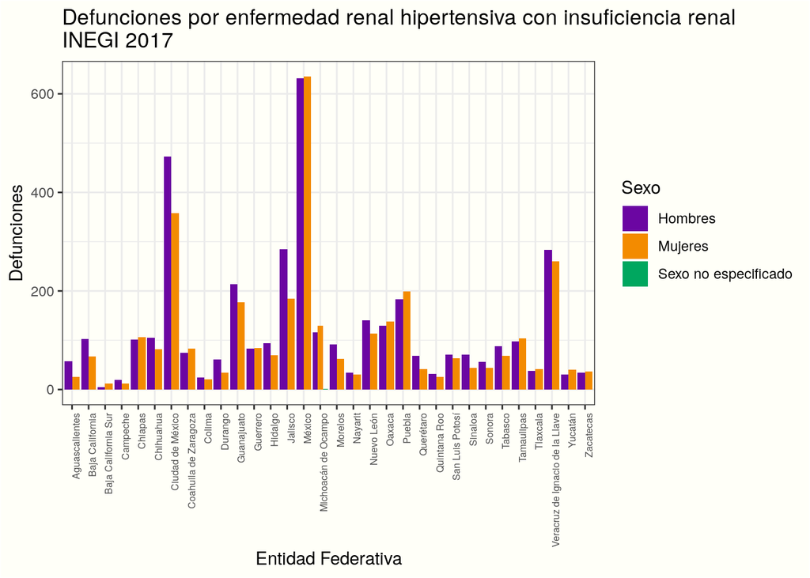